# AustinBikeShare

## Objective:

1. How much do weather and seasonality influence the Daily Cumulative Bike Rentals in Austin, Texas per day.
2. To build a predictive model for Daily Cumulative Bike Rentals in Austin, Texas based on weather and seasonality.

## Loading Data

```r
bikes = read.csv("austin_bikeshare_trips.csv", header = T)
```

```r
glimpse(bikes)
```

```
## Rows: 649,231
## Columns: 12
## $ bikeid             <dbl> 8, 141, 578, 555, 86, 861, 382, 435, 555, 668, 9...
## $ checkout_time      <chr> "19:12:00", "2:06:04", "16:28:27", "15:12:00", "...
## $ duration_minutes   <int> 41, 6, 13, 80, 25, 29, 17, 49, 19, 20, 44, 12, 2...
## $ end_station_id     <dbl> 2565, 2570, 2498, 2712, 3377, 2537, 2575, 2575, ...
## $ end_station_name   <chr> "Trinity & 6th Street", "South Congress & Academ...
## $ month              <dbl> 3, 10, 3, 11, 4, 5, 7, 1, 5, NA, 3, 9, 10, 3, 4,...
## $ start_station_id   <dbl> 2536, 2494, 2538, 2497, 2707, 2540, 2567, 2575, ...
## $ start_station_name <chr> "Waller & 6th St.", "2nd & Congress", "Bullock M...
## $ start_time         <chr> "2015-03-19 19:12:00", "2016-10-30 02:06:04", "2...
## $ subscriber_type    <chr> "Walk Up", "Local365", "Local365", "24-Hour Kios...
## $ trip_id            <dbl> 9900082882, 12617682, 9075366, 9900319298, 14468...
## $ year               <dbl> 2015, 2016, 2016, 2014, 2017, 2015, 2016, 2015, ...
```

This file contains the data corresponding to each of the bike rental in Austin, Texas.

There are two possible response variables here. 1. Daily cumulative bike rental duration in hours 2. Total Count of bike rentals per day

```r
bikes$start_date = date(bikes$start_time)
bikes2 = bikes %>%
  group_by(start_date) %>%
  summarize(TotDur = sum(duration_minutes),
            TotalCount = n()) %>%
  ungroup()
```

Loading the daily weather data and using only the average weather data for analysis because the average is more representative of the daily weather when compared to highs and lows.

```r
weather = read.csv("austin_weather.csv", header = T)
weather$Date = mdy(weather$Date)
req_cols = c("Date","TempAvgF","DewPointAvgF","HumidityAvgPercent","SeaLevelPressureAvgInches","VisibilityAvgMiles","WindAvgMPH","PrecipitationSumInches","Events")
weather = weather[req_cols]

bikes2 = bikes2 %>%
  left_join(weather, by = c("start_date"="Date"))
head(bikes2)
```

```
## # A tibble: 6 x 11
##   start_date TotDur TotalCount TempAvgF DewPointAvgF HumidityAvgPerc~
##   <date>      <int>      <int>    <int>        <dbl>            <dbl>
## 1 2013-12-21   3001        103       60           49               75
## 2 2013-12-22   4734        117       48           36               68
## 3 2013-12-23   5338         96       45           27               52
## 4 2013-12-24   2717         85       46           28               56
## 5 2013-12-25   7148        145       50           40               71
## 6 2013-12-26   4927        100       48           36               63
## # ... with 5 more variables: SeaLevelPressureAvgInches <dbl>,
## #   VisibilityAvgMiles <dbl>, WindAvgMPH <int>, PrecipitationSumInches <chr>,
## #   Events <chr>
```

## Data Cleaning

1. Precipitation has trace amounts noted as “T”. This indicates the amount of precipitation which cannot be measured (usually lower than 0.01 inches). So I replaced it with 0.005 inches. (since I know that it is higher than 0)
2. Converting the binary columns to factors.
3. Creating Month and Weekday from start date
4. Renaming the columns to shorter names for ease of use.
5. Splitting the dataset into two: One having data from 2014-2016 which is used to build the model and 2017’s data which will be used for checking predictions.

```r
bikes2$Precipitation = as.numeric(bikes2$PrecipitationSumInches)
bikes2 <- bikes2 %>%
  mutate(AdverseEvent = if_else(str_length(Events)>1,1,0)) %>%
  select(-Events) %>%
  replace(is.na(.), 0.005) %>%
  select(-PrecipitationSumInches)

bikes2$AdverseEvent = as.factor(bikes2$AdverseEvent)

bikes2$DayOfWeek = wday(bikes2$start_date,week_start = getOption("lubridate.week.start", 1))

bikes2 <- bikes2 %>%
  mutate(Weekday = if_else(DayOfWeek <=4, 1,0)) %>%
  select(-DayOfWeek)

bikes2$Weekday = as.factor(bikes2$Weekday)
bikes2$Month = month(bikes2$start_date)

newcolnames = c("start_date","TotDur","TotCnt","Temp","DewPt","Humid",
                "Pressure","Visib","WindSpd","Precip","AdvEvent","Weekday","Month")
colnames(bikes2) = newcolnames

bikes1416 <- bikes2 %>%
  filter(year(start_date) >=2014 & year(start_date)<=2016)

bikes17 <- bikes2 %>%
  filter(year(start_date) ==2017)
```

```r
glimpse(bikes1416)
```

```
## Rows: 1,034
## Columns: 13
## $ start_date <date> 2014-01-01, 2014-01-02, 2014-01-03, 2014-01-04, 2014-01...
## $ TotDur     <int> 11103, 2995, 2381, 6650, 845, 249, 834, 812, 1252, 1158,...
## $ TotCnt     <int> 267, 144, 63, 173, 44, 24, 48, 27, 76, 76, 272, 88, 80, ...
## $ Temp       <int> 54, 44, 43, 57, 47, 29, 35, 47, 62, 65, 62, 57, 57, 57, ...
## $ DewPt      <dbl> 42, 26, 22, 48, 32, 8, 11, 45, 55, 61, 37, 47, 36, 25, 2...
## $ Humid      <dbl> 68, 55, 49, 68, 59, 38, 43, 75, 80, 81, 53, 68, 51, 41, ...
## $ Pressure   <dbl> 30.11, 30.37, 30.35, 29.95, 30.08, 30.68, 30.52, 30.20, ...
## $ Visib      <dbl> 10, 10, 10, 10, 10, 10, 10, 2, 4, 8, 9, 10, 9, 10, 10, 1...
## $ WindSpd    <int> 4, 8, 4, 7, 10, 7, 5, 1, 3, 6, 3, 4, 7, 5, 4, 4, 5, 2, 3...
## $ Precip     <dbl> 0.00, 0.00, 0.00, 0.00, 0.00, 0.00, 0.00, 0.16, 0.00, 0....
## $ AdvEvent   <fct> 0, 0, 0, 0, 0, 0, 0, 1, 1, 1, 0, 1, 0, 0, 0, 0, 0, 0, 0,...
## $ Weekday    <fct> 1, 1, 0, 0, 0, 1, 1, 1, 1, 0, 0, 0, 1, 1, 1, 1, 0, 0, 0,...
## $ Month      <dbl> 1, 1, 1, 1, 1, 1, 1, 1, 1, 1, 1, 1, 1, 1, 1, 1, 1, 1, 1,...
```

Creating the final dataset for regression i.e., removing any unnecessary columns and also creating the train/test sets

```r
reg_data = bikes1416 %>% select(-c(start_date,TotCnt))
#Creating test and train
K = 10
N = nrow(reg_data)
nTest = N*K/100
KI = c(seq(1,N,1+round(nTest)),N) # gives a vector of indices for test sets
set.seed(1) #setting seed to the the same random values every time in the next line
reg_data = reg_data[sample(N),] # randomizes the rows

ind = c(KI[1]:KI[2])
test = reg_data[ind,]
train = reg_data[!(c(1:N) %in% ind),]
```

## Modeling:

This is base model with all the variables used as-is. For the purpose of Cross-Validation, we randomly converted the dataset into 10 train (90%) and test (10%) sets and the model outputs shown in the report corresponds to the first train set.

```r
model0 = lm(TotDur~. , data = train)
summary(model0)
```

```
##
## Call:
## lm(formula = TotDur ~ ., data = train)
##
## Residuals:
##    Min     1Q Median     3Q    Max
## -21905  -5097  -1878   2216  83195
##
## Coefficients:
##              Estimate Std. Error t value Pr(>|t|)
## (Intercept) 205938.41   90944.43   2.264 0.023779 *
## Temp          -147.68     163.44  -0.904 0.366476
## DewPt          281.80     173.68   1.622 0.105047
## Humid         -146.50      94.26  -1.554 0.120487
## Pressure     -5892.82    2987.65  -1.972 0.048864 *
## Visib          288.27     357.48   0.806 0.420225
## WindSpd       -465.11     176.90  -2.629 0.008703 **
## Precip       -1680.26     931.43  -1.804 0.071566 .
## AdvEvent1    -1479.74    1014.57  -1.458 0.145047
## Weekday1    -12301.49     718.77 -17.115  < 2e-16 ***
## Month         -449.10     116.54  -3.854 0.000124 ***
## ---
## Signif. codes:  0 '***' 0.001 '**' 0.01 '*' 0.05 '.' 0.1 ' ' 1
##
## Residual standard error: 10770 on 918 degrees of freedom
## Multiple R-squared:  0.285,  Adjusted R-squared:  0.2773
## F-statistic:  36.6 on 10 and 918 DF,  p-value: < 2.2e-16
```

Some of the variables are not statistically significant at an alpha of 0.05, given that the other variables are in the model. Based on the F-statistic value the overall model is significant with an adjusted R-squared of 0.28.

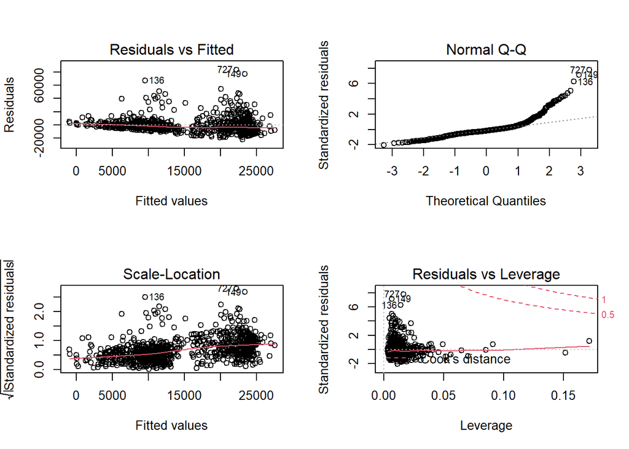

```r
par(mfrow = c(2,2))
plot(model0)
```

1. Scale-Location Plot: shows a slight curvature 2. Normal QQ plot: Shows highly skewed points. 3. Leverage Plot: Quite a lot of points with standardized residuals over 4.

Since the assumptions of MLR do not hold here we can perform transformations to fix those issues.

## Transformation of Variables

I will use the boxcox method for transformation of non-categorical variables.

```r
boxcox = powerTransform(
        cbind(TotDur, Temp, DewPt, Humid, Pressure, Visib, WindSpd) ~ -1, data = train)

summary(boxcox)
```

```
## bcPower Transformations to Multinormality
##          Est Power Rounded Pwr Wald Lwr Bnd Wald Upr Bnd
## TotDur      0.1439        0.14       0.0934       0.1944
## Temp        1.0624        1.00       0.9478       1.1770
## DewPt       1.0449        1.00       0.9691       1.1207
## Humid       0.5669        0.50       0.4371       0.6968
## Pressure   -6.4499       -6.45      -6.4691      -6.4307
## Visib       6.6861        6.69       6.1024       7.2699
## WindSpd     0.5351        0.50       0.4123       0.6579
##
## Likelihood ratio test that transformation parameters are equal to 0
##  (all log transformations)
##                                        LRT df       pval
## LR test, lambda = (0 0 0 0 0 0 0) 2356.438  7 < 2.22e-16
##
## Likelihood ratio test that no transformations are needed
##                                        LRT df       pval
## LR test, lambda = (1 1 1 1 1 1 1) 1605.618  7 < 2.22e-16
```

I will create a new dataframe with transformed variables and also use a few interactions based on general knowledge.

1. Month and Temperature
2. Temperature and Dew
3. Temperature and Humidity
4. Visibility and Humidity
5. Wind and Pressure

```r
#Transforming the variables
ttrain = NULL
ttrain$tTotDur = train$TotDur^0.15
ttrain$Weekday = train$Weekday
ttrain$sinMonth = sin(2*pi*train$Month/12)
ttrain$cosMonth = cos(2*pi*train$Month/12)
ttrain$Temp = train$Temp
ttrain$DewPt = train$DewPt
ttrain$tHumid = train$Humid^0.5
ttrain$tPressure = train$Pressure^-6.35
ttrain$tVisib = train$Visib^6.66
ttrain$tWindSpd = train$WindSpd^0.5
ttrain$AdvEvent = train$AdvEvent
ttrain = as.data.frame(ttrain)
ttrain$Weekday = as.factor(ttrain$Weekday)
ttrain$AdvEvent = as.factor(ttrain$AdvEvent)

#interactions
ttrain$sinM_Temp = ttrain$sinMonth*ttrain$Temp
ttrain$cosM_Temp = ttrain$cosMonth*ttrain$Temp
ttrain$Temp_Dew = ttrain$Temp*ttrain$DewPt
ttrain$Temp_tHumid = ttrain$Temp*ttrain$tHumid
ttrain$tVisib_tHumid = ttrain$tVisib*ttrain$tHumid
ttrain$tWind_tPressure = ttrain$tWindSpd*ttrain$tPressure
glimpse(ttrain)
```

```
## Rows: 929
## Columns: 17
## $ tTotDur         <dbl> 4.340403, 3.027644, 3.283942, 3.937081, 4.796780, 4...
## $ Weekday         <fct> 0, 1, 1, 1, 0, 1, 1, 1, 0, 0, 1, 1, 0, 1, 0, 0, 1, ...
## $ sinMonth        <dbl> 8.660254e-01, -5.000000e-01, 8.660254e-01, -1.00000...
## $ cosMonth        <dbl> -5.000000e-01, 8.660254e-01, 5.000000e-01, -1.83691...
## $ Temp            <int> 73, 36, 70, 86, 76, 79, 65, 62, 84, 78, 73, 69, 60,...
## $ DewPt           <dbl> 66, 13, 50, 73, 64, 45, 49, 50, 70, 67, 64, 59, 46,...
## $ tHumid          <dbl> 8.888194, 6.557439, 6.928203, 8.366600, 8.185353, 6...
## $ tPressure       <dbl> 4.389660e-10, 3.740143e-10, 4.306292e-10, 4.180223e...
## $ tVisib          <dbl> 2265975.0, 4570881.9, 2265975.0, 4570881.9, 4570881...
## $ tWindSpd        <dbl> 2.645751, 2.828427, 2.828427, 2.449490, 1.414214, 2...
## $ AdvEvent        <fct> 0, 0, 0, 0, 0, 0, 0, 0, 0, 1, 0, 1, 1, 0, 1, 0, 1, ...
## $ sinM_Temp       <dbl> 6.321985e+01, -1.800000e+01, 6.062178e+01, -8.60000...
## $ cosM_Temp       <dbl> -3.650000e+01, 3.117691e+01, 3.500000e+01, -1.57974...
## $ Temp_Dew        <dbl> 4818, 468, 3500, 6278, 4864, 3555, 3185, 3100, 5880...
## $ Temp_tHumid     <dbl> 648.8382, 236.0678, 484.9742, 719.5276, 622.0868, 5...
## $ tVisib_tHumid   <dbl> 20140426, 29973277, 15699135, 38242742, 37414281, 3...
## $ tWind_tPressure <dbl> 1.161395e-09, 1.057872e-09, 1.218003e-09, 1.023941e...
```

```r
tmodel1 <- lm(tTotDur ~ ., data = ttrain)
summary(tmodel1)
```

```
##
## Call:
## lm(formula = tTotDur ~ ., data = ttrain)
##
## Residuals:
##      Min       1Q   Median       3Q      Max
## -1.31665 -0.21790 -0.02716  0.18243  1.60954
##
## Coefficients:
##                   Estimate Std. Error t value Pr(>|t|)
## (Intercept)      8.262e+00  1.729e+00   4.779 2.06e-06 ***
## Weekday1        -5.050e-01  2.318e-02 -21.783  < 2e-16 ***
## sinMonth        -6.036e-01  1.510e-01  -3.999 6.89e-05 ***
## cosMonth        -8.781e-01  1.800e-01  -4.878 1.27e-06 ***
## Temp             5.914e-03  1.057e-02   0.559 0.576056
## DewPt            3.107e-02  1.010e-02   3.076 0.002164 **
## tHumid          -3.901e-01  1.086e-01  -3.592 0.000346 ***
## tPressure       -6.434e+09  3.777e+09  -1.704 0.088810 .
## tVisib          -2.831e-07  1.027e-07  -2.756 0.005963 **
## tWindSpd        -8.254e-01  6.778e-01  -1.218 0.223657
## AdvEvent1       -9.312e-02  3.369e-02  -2.764 0.005818 **
## sinM_Temp        1.049e-02  2.176e-03   4.822 1.67e-06 ***
## cosM_Temp        1.212e-02  2.489e-03   4.869 1.32e-06 ***
## Temp_Dew        -3.924e-04  1.245e-04  -3.152 0.001673 **
## Temp_tHumid      3.009e-03  1.476e-03   2.039 0.041746 *
## tVisib_tHumid    3.721e-08  1.183e-08   3.146 0.001711 **
## tWind_tPressure  1.734e+09  1.638e+09   1.059 0.290019
## ---
## Signif. codes:  0 '***' 0.001 '**' 0.01 '*' 0.05 '.' 0.1 ' ' 1
##
## Residual standard error: 0.3454 on 912 degrees of freedom
## Multiple R-squared:  0.5826, Adjusted R-squared:  0.5753
## F-statistic: 79.55 on 16 and 912 DF,  p-value: < 2.2e-16
```

The transformed. model is a lot better than the base model with a much higher adjusted R-squared value with a few significant interactions. But there is some redundant information which can be removed using data driven Model Selection

```r
backBIC <- step(tmodel1, direction="backward", data=ttrain, k = log(nrow(ttrain)))
backAIC <- step(tmodel1, direction="backward", data=ttrain)
```

THe model obtained from running Backward Elimination using BIC is as follows

1. Weekday
2. sinM_Temp
3. cosM_Temp
4. sinMonth
5. cosMonth
6. DewPt
7. tHumid
8. tWindSpd
9. AdvEvent
10. tVisib_tHumid

Seven of these are the actual variables and three are interactions.

The variables obtained from using Backward Elimination with AIC is as follows

1. tPressure
2. tVisib
3. AdvEvent
4. tVisib_tHumid
5. Temp_Dew
6. Temp_tHumid
7. DewPt
8. sinMonth
9. tWindSpd
10. cosM_Temp
11. cosMonth
12. sinM_Temp
13. tHumid
14. Weekday

```r
modelaic <- lm(tTotDur ~ Weekday + sinM_Temp + cosM_Temp + sinMonth + cosMonth +
                 DewPt + tHumid + tPressure + tVisib + tWindSpd + AdvEvent +
                 tVisib_tHumid + Temp_tHumid + Temp_Dew,
               data = ttrain)
summary(modelaic)
```

```
##
## Call:
## lm(formula = tTotDur ~ Weekday + sinM_Temp + cosM_Temp + sinMonth +
##     cosMonth + DewPt + tHumid + tPressure + tVisib + tWindSpd +
##     AdvEvent + tVisib_tHumid + Temp_tHumid + Temp_Dew, data = ttrain)
##
## Residuals:
##      Min       1Q   Median       3Q      Max
## -1.31994 -0.21634 -0.03038  0.18003  1.59651
##
## Coefficients:
##                 Estimate Std. Error t value Pr(>|t|)
## (Intercept)    6.995e+00  6.425e-01  10.887  < 2e-16 ***
## Weekday1      -5.069e-01  2.312e-02 -21.922  < 2e-16 ***
## sinM_Temp      1.051e-02  2.137e-03   4.918 1.04e-06 ***
## cosM_Temp      1.197e-02  2.484e-03   4.817 1.70e-06 ***
## sinMonth      -6.037e-01  1.492e-01  -4.047 5.61e-05 ***
## cosMonth      -8.657e-01  1.794e-01  -4.825 1.64e-06 ***
## DewPt          3.292e-02  9.719e-03   3.388 0.000735 ***
## tHumid        -4.344e-01  7.562e-02  -5.745 1.25e-08 ***
## tPressure     -2.500e+09  1.174e+09  -2.130 0.033475 *
## tVisib        -2.735e-07  1.016e-07  -2.692 0.007229 **
## tWindSpd      -1.087e-01  2.633e-02  -4.127 4.01e-05 ***
## AdvEvent1     -9.882e-02  3.308e-02  -2.987 0.002889 **
## tVisib_tHumid  3.605e-08  1.168e-08   3.085 0.002096 **
## Temp_tHumid    3.591e-03  1.063e-03   3.380 0.000756 ***
## Temp_Dew      -3.965e-04  1.243e-04  -3.190 0.001472 **
## ---
## Signif. codes:  0 '***' 0.001 '**' 0.01 '*' 0.05 '.' 0.1 ' ' 1
##
## Residual standard error: 0.3453 on 914 degrees of freedom
## Multiple R-squared:  0.5819, Adjusted R-squared:  0.5755
## F-statistic: 90.86 on 14 and 914 DF,  p-value: < 2.2e-16
```

Both the models obtained from Backward AIC and BIC provide approximately the same adjusted R-squared values where one has 10 factors while the other has 14.

Now let’s look at the all possible subsets output.

```
##    SubsetSize     AdjR2       AIC       BIC Weekday sinMonth cosMonth Temp
## 1           1 0.2443673 -1275.716 -1266.285       1        0        0    0
## 2           2 0.3798083 -1437.679 -1423.532       1        0        0    1
## 3           3 0.4277009 -1502.986 -1484.124       1        0        0    1
## 4           4 0.4855248 -1589.866 -1566.289       1        0        0    1
## 5           5 0.5179160 -1642.521 -1614.229       1        0        0    0
## 6           6 0.5296026 -1661.775 -1628.767       1        0        0    0
## 7           7 0.5452497 -1688.693 -1650.970       1        1        1    1
## 8           8 0.5615467 -1717.812 -1675.374       1        1        1    1
## 9           9 0.5655185 -1724.331 -1677.178       1        1        1    1
## 10         10 0.5671529 -1726.453 -1674.584       1        1        1    0
## 11         11 0.5692339 -1729.444 -1672.859       1        1        1    1
## 12         12 0.5699717 -1729.873 -1668.573       1        1        1    1
## 13         13 0.5719396 -1732.674 -1666.658       1        1        1    0
## 14         14 0.5729527 -1733.647 -1662.916       1        1        1    0
```

[output cut: 36 more lines]

This shows the model with highest adjusted R-squared values for each subset size and their AIC and BIC values.

Subset size 9 is the balance between over-fitting and under-fitting which is different from the ones obtained using Backward Elimination with AIC (Size=14) and BIC (Size = 10).

Now, let’s look at the model summary for the subset size 9.

```r
modelsize9 <- lm(tTotDur ~ Weekday + sinMonth + cosMonth + Temp + tVisib +
                   AdvEvent + sinM_Temp + cosM_Temp + tWind_tPressure,
                 data = ttrain)
summary(modelsize9)
```

```
##
## Call:
## lm(formula = tTotDur ~ Weekday + sinMonth + cosMonth + Temp +
##     tVisib + AdvEvent + sinM_Temp + cosM_Temp + tWind_tPressure,
##     data = ttrain)
##
## Residuals:
##      Min       1Q   Median       3Q      Max
## -1.31072 -0.22893 -0.03932  0.18475  1.64781
##
## Coefficients:
##                   Estimate Std. Error t value Pr(>|t|)
## (Intercept)      3.647e+00  1.458e-01  25.005  < 2e-16 ***
## Weekday1        -5.101e-01  2.319e-02 -21.995  < 2e-16 ***
## sinMonth        -9.107e-01  1.099e-01  -8.287 4.10e-16 ***
## cosMonth        -1.183e+00  1.350e-01  -8.764  < 2e-16 ***
## Temp             1.487e-02  1.902e-03   7.819 1.46e-14 ***
## tVisib           4.573e-08  9.022e-09   5.069 4.83e-07 ***
## AdvEvent1       -1.000e-01  3.257e-02  -3.071  0.00219 **
## sinM_Temp        1.545e-02  1.453e-03  10.635  < 2e-16 ***
## cosM_Temp        1.690e-02  1.713e-03   9.868  < 2e-16 ***
## tWind_tPressure -3.266e+08  5.981e+07  -5.461 6.09e-08 ***
## ---
## Signif. codes:  0 '***' 0.001 '**' 0.01 '*' 0.05 '.' 0.1 ' ' 1
##
## Residual standard error: 0.3486 on 919 degrees of freedom
## Multiple R-squared:  0.5717, Adjusted R-squared:  0.5675
## F-statistic: 136.3 on 9 and 919 DF,  p-value: < 2.2e-16
```

# Comparing RMSE for several models

I created the models based on the output from the all-possible subsets and calculated the RMSE and adjusted R-squared values. The results of which are shown below.

The models include from the Full Model (16 factors) to the one with Subset Size 7. It also includes the ones obtained from Backward AIC and BIC.

```r
models = c("MFull", "Mbic","Maic","MSize15","MSize14","MSize13","MSize12",
           "MSize11","MSize10","MSize9","MSize8","MSize7")
rmse = as.data.frame(round(rmse))
colnames(rmse) = models
rmse
```

```
##    MFull  Mbic  Maic MSize15 MSize14 MSize13 MSize12 MSize11 MSize10 MSize9
## 1   8618  8790  8565    8608    8565    8568    8685    8691    8640   8893
## 2   9862  9830  9857    9855    9857    9832    9833    9814    9836   9787
## 3  14890 14908 14812   14835   14812   14842   15064   15108   14990  15014
## 4   9581  9651  9574    9584    9574    9568    9634    9636    9650   9627
## 5   9881 10086  9890    9884    9890    9924    9841    9880    9955  10053
## 6  10231 10466 10242   10231   10242   10319   10337   10410   10384  10459
## 7   7963  8017  7945    7952    7945    7943    7883    7899    7981   7966
## 8  13052 12931 13014   13032   13014   13069   13010   13080   12959  12981
## 9   7411  7460  7397    7397    7397    7369    7489    7456    7476   7451
## 10  7957  8150  7980    7967    7980    8006    8085    8098    8110   8136
##    MSize8 MSize7
## 1    8953   8978
## 2    9761   9795
## 3   14990  15037
## 4    9693   9610
## 5   10116   9981
## 6   10502  10506
## 7    8116   7918
## 8   13114  13443
## 9    7473   7570
## 10   8100   8386
```

```r
adjR2 = as.data.frame(100*round(adjR2,4))
colnames(adjR2) = models
adjR2
```

```
##    MFull  Mbic  Maic MSize15 MSize14 MSize13 MSize12 MSize11 MSize10 MSize9
## 1  57.53 56.81 57.55   57.56   57.55   57.46   57.15   57.02   57.03  56.75
## 2  57.31 56.46 57.35   57.35   57.35   57.20   56.95   56.74   56.83  56.34
## 3  57.98 56.83 57.97   57.96   57.97   57.87   57.62   57.46   57.32  56.91
## 4  57.95 57.08 58.00   57.99   58.00   57.91   57.48   57.37   57.46  56.90
## 5  56.26 55.29 56.35   56.31   56.35   56.26   55.55   55.43   55.55  55.14
## 6  58.32 57.37 58.39   58.37   58.39   58.31   57.68   57.57   57.61  57.29
## 7  57.24 56.21 57.28   57.28   57.28   57.15   56.48   56.36   56.61  55.88
## 8  55.64 54.37 55.65   55.64   55.65   55.56   55.09   54.95   54.90  54.34
## 9  56.93 56.06 57.01   56.97   57.01   56.85   56.60   56.38   56.53  55.87
## 10 56.83 55.98 56.89   56.87   56.89   56.78   56.46   56.30   56.37  55.85
##    MSize8 MSize7
## 1   56.35  54.89
## 2   55.77  54.21
## 3   56.45  54.97
## 4   56.32  54.73
## 5   54.57  53.28
## 6   56.67  55.48
## 7   55.42  53.55
## 8   53.85  52.25
## 9   55.34  53.87
## 10  55.28  53.74
```

The table below shows the average RMSE and average adjusted R-squared values for each model.

```r
rmse_Means = colMeans(rmse)
adjR2_Means = colMeans(adjR2)
t(rbind(rmse_Means,adjR2_Means))
```

```
##         rmse_Means adjR2_Means
## MFull       9944.6      57.199
## Mbic       10028.9      56.246
## Maic        9927.6      57.244
## MSize15     9934.5      57.230
## MSize14     9927.6      57.244
## MSize13     9944.0      57.135
## MSize12     9986.1      56.706
## MSize11    10007.2      56.558
## MSize10     9998.1      56.621
## MSize9     10036.7      56.127
## MSize8     10081.8      55.602
## MSize7     10122.4      54.097
```

Model obtained with Backward Elimination using AIC has the smallest RMSE value which also has the highest average adjusted R-squared value.

Let’s look at the diagnostics of the Model obtained from Backward Elimination with AIC to check the validity of the model.

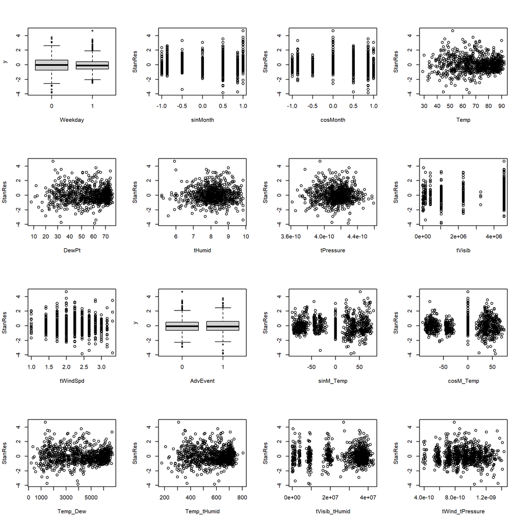

```r
modelaic <- lm(tTotDur ~ Weekday + sinM_Temp + cosM_Temp + sinMonth + cosMonth +
                 DewPt + tHumid + tPressure + tVisib + tWindSpd + AdvEvent +
                 tVisib_tHumid + Temp_tHumid + Temp_Dew,
               data = ttrain)
StanRes = rstandard(modelaic)
par(mfrow = c(4,4))
for(i in 1:(ncol(ttrain)-1)){
  plot(ttrain[,i+1],StanRes, xlab = colnames(ttrain)[i+1])
}
```

There are no obvious patterns in each of the residuals plots so we can say that nothing is wrong with the model so far.

```r
par(mfrow = c(4,4))
for(i in 1:(ncol(ttrain)-1)){
  if(!is.factor(ttrain[,i+1])){
    mmp(modelaic, ttrain[,i+1], xlab = colnames(ttrain)[i+1])
  }else{
    mmp(modelaic, as.numeric(ttrain[,i+1]), xlab = colnames(ttrain)[i+1])
  }
}
```

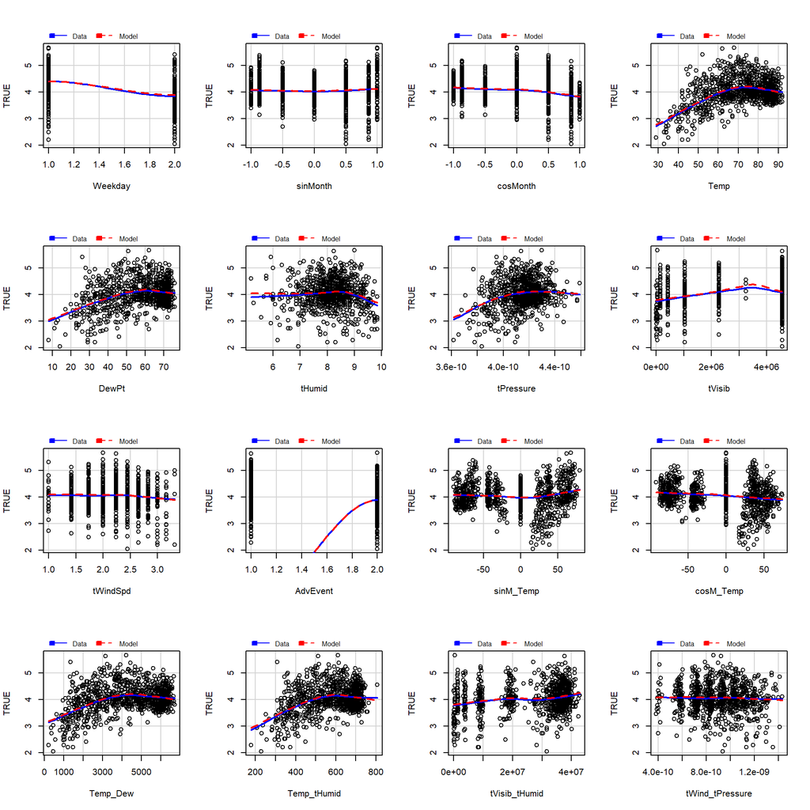

The marginal model plots shows the comparison of the linear model and the non-parametric model. Since both of them are very close to each other we can conclude that linearity assumption holds. (the adverse event plot looks weird, this may be due to the fact that this variable is a categorical variable.)

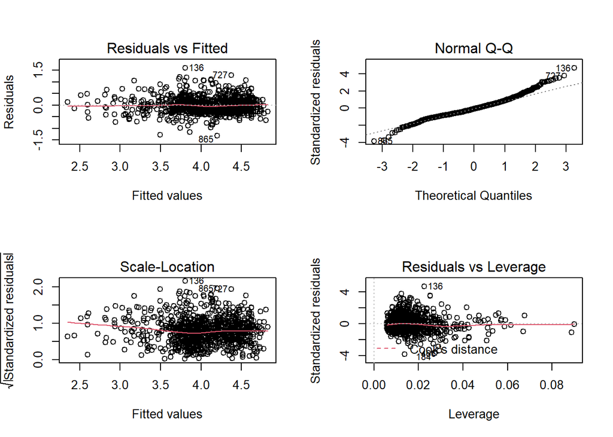

```r
par(mfrow = c(2,2))
plot(modelaic)
```

Normal QQ plot: Mostly normal with heavy tails. Leverage Plot: No Influential Points. No bad leverage points.